# Lab 1.2: Introduction to tidy *R*

July 2023

# Contents

Authors: Martin Morgan, Sonali Arora, Lori Shepherd  
Back: Intro labs

**Objective**: Gain confidence working with ‘tidy’ R commands and data structures.

**Lessons learned**:

- Basic data input using readr.
- Working with tibbles using common dplyr ‘verbs’.
- Using `pivot_longer()` to ‘tidy’ data.
- Introduction to writing our own tidy functions.
- Visualization using base R and ggplot2.

# 1 Introduction to the tidyverse

The ‘tidyverse’ is a a recent approach to working with data in *R*. The basic principle is that data is often best represented in ‘long-form’ data.frames, with data transformations implemented with a few central functions.

Start by loading some important packages in the tidyverse, *readr* for data input, *tibble* for data representation, *dplyr* for manipulation, and *ggplot2* for visualization.

```r
library(readr)
library(tibble)
library(dplyr)
library(ggplot2)
```

Read the BRFSS data into a `tibble` (data.frame) using `read_csv()`; this function is similar to `read.csv()` but standardized the argument naming convention.

```r
fname <- file.choose()   ## BRFSS-subset.csv
stopifnot(file.exists(fname))
brfss <- read_csv(fname)
```

Note that by default character values were *not* interpreted as factors, that the display is more informative (the class of each column is indicated under the title), and only a ‘preview’ of all the data is displayed.

```r
brfss
```

```
## # A tibble: 20,000 × 5
##      Age Weight Sex    Height  Year
##    <dbl>  <dbl> <chr>   <dbl> <dbl>
##  1    31   49.0 Female   157.  1990
##  2    57   81.6 Female   157.  1990
##  3    43   80.3 Male     178.  1990
##  4    72   70.3 Male     170.  1990
##  5    31   49.9 Female   155.  1990
##  6    58   54.4 Female   155.  1990
##  7    45   69.9 Male     173.  1990
##  8    37   68.0 Male     180.  1990
##  9    33   65.8 Female   170.  1990
## 10    75   70.8 Female   152.  1990
## # ℹ 19,990 more rows
```

A `tibble()` can be manipulated like a data.frame, but usually operations in the tidyverse are ‘piped’ using the `|>` symbol from one representation to another. We start with some clean-up using the `mutate()` function to update or add individual columns. Start with an interactive exploration…

```r
brfss |>
    mutate( Sex = factor(Sex), Year = factor(Year) )
```

```
## # A tibble: 20,000 × 5
##      Age Weight Sex    Height Year
##    <dbl>  <dbl> <fct>   <dbl> <fct>
##  1    31   49.0 Female   157. 1990
##  2    57   81.6 Female   157. 1990
##  3    43   80.3 Male     178. 1990
##  4    72   70.3 Male     170. 1990
##  5    31   49.9 Female   155. 1990
##  6    58   54.4 Female   155. 1990
##  7    45   69.9 Male     173. 1990
##  8    37   68.0 Male     180. 1990
##  9    33   65.8 Female   170. 1990
## 10    75   70.8 Female   152. 1990
## # ℹ 19,990 more rows
```

…and when the pipeline looks good re-assign the updated tibble.

```r
brfss <-
    brfss |>
    mutate( Sex = factor(Sex), Year = factor(Year) )
```

Common operations are to `filter()` rows to those containing only certain values, and to `select()` a subset of columns.

```r
brfss |>
    filter(Sex == "Female", Year == "1990") |>
    select(Age, Weight, Height)
```

```
## # A tibble: 5,718 × 3
##      Age Weight Height
##    <dbl>  <dbl>  <dbl>
##  1    31   49.0   157.
##  2    57   81.6   157.
##  3    31   49.9   155.
##  4    58   54.4   155.
##  5    33   65.8   170.
##  6    75   70.8   152.
##  7    68   66.2   160.
##  8    87   49.9   152.
##  9    44  115.    160.
## 10    57   63.5   157.
## # ℹ 5,708 more rows
```

Another common operation is to `group_by()` one or more columns, and `summarize()` data in other columns, e.g.,

```r
brfss |>
    group_by(Sex, Year) |>
    summarize(
        AveAge = mean(Age, na.rm=TRUE),
        AveWeight = mean(Weight, na.rm=TRUE)
    )
```

[output not shown]

```
## # A tibble: 4 × 4
## # Groups:   Sex [2]
##   Sex    Year  AveAge AveWeight
##   <fct>  <fct>  <dbl>     <dbl>
## 1 Female 1990    46.2      64.8
## 2 Female 2010    57.1      73.0
## 3 Male   1990    43.9      81.2
## 4 Male   2010    56.2      88.8
```

Note that the output of each pipe is itself a tibble, so that the output can be further transformed using tidyverse functions.

The main features of ‘tidy’ data are

1. Standard representation as a long-format data.frame-like `tibble()`
2. Restricted vocabulary of core functions – `mutate()`, `filter()`, `select()`, `group_by()`, `summarize()`, … These functions are ‘isomorphic’, meaning that the return value is the same type (a tibble!) as the first argument of the function.
3. Short ‘pipes’ summarizing data transformation steps.

# 2 Case studies

## 2.1 Revisiting the ALL phenotypic data

### 2.1.1 Data input and basic manipulation

Revisit case study 2.1, ALL Phenotype Data in Lab 1.1: Introduction to *R* using a tidy approach to data exploration.

1. Input the data “ALLphenoData.tsv” using `read_tsv()` (note: we use `_tsv()` because the columns are _t_ab _s_eparated). Compare column types, display, etc with base *R* functions. Note that columns are never `factor()` by default.
2. Use `filter()` to create a subset of the data consisting only of female individuals over 40. Compare this approach with that used in base *R*. Likewise, create a subsect with only “BCR/ABL” and “NEG” in the `mol.biol` column.
3. Use `mutate()` to further transform the bcrabl subset by recoding the `BT` column to be either B or T, based on the first letter of the column.
4. Use `group_by()` and `summarize()` to deterimine the number of individuals in each combination of `BT` and `mol.biol`. Can you perform this same computation using only `count()`?

### 2.1.2 Using un-tidy functions: `t.test()`

We’d like to compare the average age of males and females in the study using `t.test()`. In base *R* , we can write

```r
pdata <- read_tsv("ALLphenoData.tsv")
t.test(age ~ sex, pdata)
```

```
##
##  Welch Two Sample t-test
##
## data:  age by sex
## t = 1.6034, df = 79.88, p-value = 0.1128
## alternative hypothesis: true difference in means between group F and group M is not equal to 0
## 95 percent confidence interval:
##  -1.022660  9.504142
## sample estimates:
## mean in group F mean in group M
##        35.16667        30.92593
```

```r
pdata |>
    t.test(age ~ sex, data = _)
```

**Exercise** Perform a t-test to ask whether there is evidence of differences in ages between the sexes. How can we change the default value of `var.equal` to `TRUE`? Is this appropriate?

**Exercise** Write a function that makes it easier to use `t.test()` in a ‘tidy’ work flow. Do this by arranging it so that the first argument of your function is the data set, the second argument the formula, and then allow for any number of additional arguments. Pass these to `t.test()`, along the lines of

```r
t_test <- function(data, formula, ...) {
    t.test(formula, data, ...)
}
```

Verify that you can use your `t_test()` function in a straight-forward way

```r
pdata |>
    t_test(age ~ sex)
```

```
##
##  Welch Two Sample t-test
##
## data:  age by sex
## t = 1.6034, df = 79.88, p-value = 0.1128
## alternative hypothesis: true difference in means between group F and group M is not equal to 0
## 95 percent confidence interval:
##  -1.022660  9.504142
## sample estimates:
## mean in group F mean in group M
##        35.16667        30.92593
```

**Exercise (advanced)** The return value of `t.test()` doesn’t fit well with `tidy` data analysis, because it is a complicated object that is not represented as a `tibble` and hence cannot be computed upon using the common tidy verbs. Update `t_test()` so that it is more tidy-friendly, accepting `data =` as it’s first argument, using `t.test()` internally to compute results, and returning a `tibble` containing results formatted for subsequent computation. One way to accomplish the last task is through use of broom`::tidy()` function to transform many base *R* objects into tidy-friendly data structures.

## 2.2 Tidying the ‘airway’ data

We’ll encounter the ‘airway’ data set extensively later in the course. Here we read in the description of 8 samples used in a RNAseq analysis, usnig `select()` to choose specific columns to work with.

```r
pdata_file <- file.choose()    # airway-sample-sheet.csv
count_file <- file.choose()    # airway-read-counts.csv
```

```r
pdata <- read_csv(pdata_file)
pdata <-
    pdata |>
    select(Run, cell, dex)
pdata
```

```
## # A tibble: 8 × 3
##   Run        cell    dex
##   <chr>      <chr>   <chr>
## 1 SRR1039508 N61311  untrt
## 2 SRR1039509 N61311  trt
## 3 SRR1039512 N052611 untrt
## 4 SRR1039513 N052611 trt
## 5 SRR1039516 N080611 untrt
## 6 SRR1039517 N080611 trt
## 7 SRR1039520 N061011 untrt
## 8 SRR1039521 N061011 trt
```

```r
count_file <- "airway-read-counts.csv"
counts <- read_csv(count_file)
eg <- counts[, 1:6]    # make it easy to work with
eg
```

```
## # A tibble: 8 × 6
##   Run        ENSG00000000003 ENSG00000000419 ENSG00000000457 ENSG00000000460
##   <chr>                <dbl>           <dbl>           <dbl>           <dbl>
## 1 SRR1039508             679             467             260              60
## 2 SRR1039509             448             515             211              55
## 3 SRR1039512             873             621             263              40
## 4 SRR1039513             408             365             164              35
## 5 SRR1039516            1138             587             245              78
## 6 SRR1039517            1047             799             331              63
## 7 SRR1039520             770             417             233              76
## 8 SRR1039521             572             508             229              60
## # ℹ 1 more variable: ENSG00000000938 <dbl>
```

An advanced tidy concept is to *join* to data sets, as described on the help page `?left_join`. Use `left_join()` to combine the phenotypic and expression data.

```r
data <- left_join(pdata, eg, by = "Run")
data
```

```
## # A tibble: 8 × 8
##   Run        cell    dex   ENSG00000000003 ENSG00000000419 ENSG00000000457
##   <chr>      <chr>   <chr>           <dbl>           <dbl>           <dbl>
## 1 SRR1039508 N61311  untrt             679             467             260
## 2 SRR1039509 N61311  trt               448             515             211
## 3 SRR1039512 N052611 untrt             873             621             263
## 4 SRR1039513 N052611 trt               408             365             164
## 5 SRR1039516 N080611 untrt            1138             587             245
## 6 SRR1039517 N080611 trt              1047             799             331
## 7 SRR1039520 N061011 untrt             770             417             233
## 8 SRR1039521 N061011 trt               572             508             229
## # ℹ 2 more variables: ENSG00000000460 <dbl>, ENSG00000000938 <dbl>
```

This is how a statistician might organize their data – in a ‘wide’ format, with each line representing a sample and each column a variable measured on that sample.

Tidy data is usually transformed into ‘long’ format, where ‘Count’ is interpreted as a measurement, with ‘Gene’ and ‘Run’ as indicator variables describing which experimental entity the count is associated with.

Use `pivot_longer()` to transform the wide format data into long-format ‘tidy’ data. `pivot_longer()` is a tricky function to work with, so study the help page carefully.

```r
library(tidyr)
```

```r
tbl <- pivot_longer(data, -(1:3), names_to = "Gene", values_to = "Count")
tbl
```

```
## # A tibble: 40 × 5
##    Run        cell   dex   Gene            Count
##    <chr>      <chr>  <chr> <chr>           <dbl>
##  1 SRR1039508 N61311 untrt ENSG00000000003   679
##  2 SRR1039508 N61311 untrt ENSG00000000419   467
##  3 SRR1039508 N61311 untrt ENSG00000000457   260
##  4 SRR1039508 N61311 untrt ENSG00000000460    60
##  5 SRR1039508 N61311 untrt ENSG00000000938     0
##  6 SRR1039509 N61311 trt   ENSG00000000003   448
##  7 SRR1039509 N61311 trt   ENSG00000000419   515
##  8 SRR1039509 N61311 trt   ENSG00000000457   211
##  9 SRR1039509 N61311 trt   ENSG00000000460    55
## 10 SRR1039509 N61311 trt   ENSG00000000938     0
## # ℹ 30 more rows
```

Use `group_by()` and `summarize()` to calculate the library size, i.e., the total number of reads mapped per run. Likewise use `group_by()` and `summarize()` to descrbe average and log-transformed counts.

```r
tbl |>
    group_by(Run) |>
    summarize(lib_size = sum(Count))
```

```
## # A tibble: 8 × 2
##   Run        lib_size
##   <chr>         <dbl>
## 1 SRR1039508     1466
## 2 SRR1039509     1229
## 3 SRR1039512     1799
## 4 SRR1039513      972
## 5 SRR1039516     2049
## 6 SRR1039517     2240
## 7 SRR1039520     1496
## 8 SRR1039521     1369
```

```r
tbl |>
    group_by(Gene) |>
    summarize(
        ave_count = mean(Count),
        ave_log_count = mean(log(1 + Count))
    )
```

```
## # A tibble: 5 × 3
##   Gene            ave_count ave_log_count
##   <chr>               <dbl>         <dbl>
## 1 ENSG00000000003   742.            6.55
## 2 ENSG00000000419   535.            6.26
## 3 ENSG00000000457   242             5.48
## 4 ENSG00000000460    58.4           4.05
## 5 ENSG00000000938     0.375         0.224
```

Now tidy all the data.

```r
counts_tbl <- pivot_longer(counts, -Run, names_to = "Gene", values_to = "Count")
```

and join to the `pdata`

```r
data_tbl <- left_join(pdata, counts_tbl)
data_tbl
```

```
## # A tibble: 267,752 × 5
##    Run        cell   dex   Gene            Count
##    <chr>      <chr>  <chr> <chr>           <dbl>
##  1 SRR1039508 N61311 untrt ENSG00000000003   679
##  2 SRR1039508 N61311 untrt ENSG00000000419   467
##  3 SRR1039508 N61311 untrt ENSG00000000457   260
##  4 SRR1039508 N61311 untrt ENSG00000000460    60
##  5 SRR1039508 N61311 untrt ENSG00000000938     0
##  6 SRR1039508 N61311 untrt ENSG00000000971  3251
##  7 SRR1039508 N61311 untrt ENSG00000001036  1433
##  8 SRR1039508 N61311 untrt ENSG00000001084   519
##  9 SRR1039508 N61311 untrt ENSG00000001167   394
## 10 SRR1039508 N61311 untrt ENSG00000001460   172
## # ℹ 267,742 more rows
```

Summarize library size (what are the maximum and minimum library sizes?)

```r
data_tbl |>
    group_by(Run) |>
    summarize(lib_size = sum(Count))
```

```
## # A tibble: 8 × 2
##   Run        lib_size
##   <chr>         <dbl>
## 1 SRR1039508 20637971
## 2 SRR1039509 18809481
## 3 SRR1039512 25348649
## 4 SRR1039513 15163415
## 5 SRR1039516 24448408
## 6 SRR1039517 30818215
## 7 SRR1039520 19126151
## 8 SRR1039521 21164133
```

and average ‘expression’ of each gene.

```r
gene_summaries <-
    data_tbl |>
    group_by(Gene) |>
    summarize(
        ave_count = mean(Count),
        ave_log_count = mean(log(1 + Count))
    )
gene_summaries
```

```
## # A tibble: 33,469 × 3
##    Gene            ave_count ave_log_count
##    <chr>               <dbl>         <dbl>
##  1 ENSG00000000003   742.            6.55
##  2 ENSG00000000419   535.            6.26
##  3 ENSG00000000457   242             5.48
##  4 ENSG00000000460    58.4           4.05
##  5 ENSG00000000938     0.375         0.224
##  6 ENSG00000000971  6035.            8.63
##  7 ENSG00000001036  1305             7.15
##  8 ENSG00000001084   615.            6.40
##  9 ENSG00000001167   392.            5.89
## 10 ENSG00000001460   188.            5.21
## # ℹ 33,459 more rows
```

And visualize using `ggplot2`

```r
library(ggplot2)
```

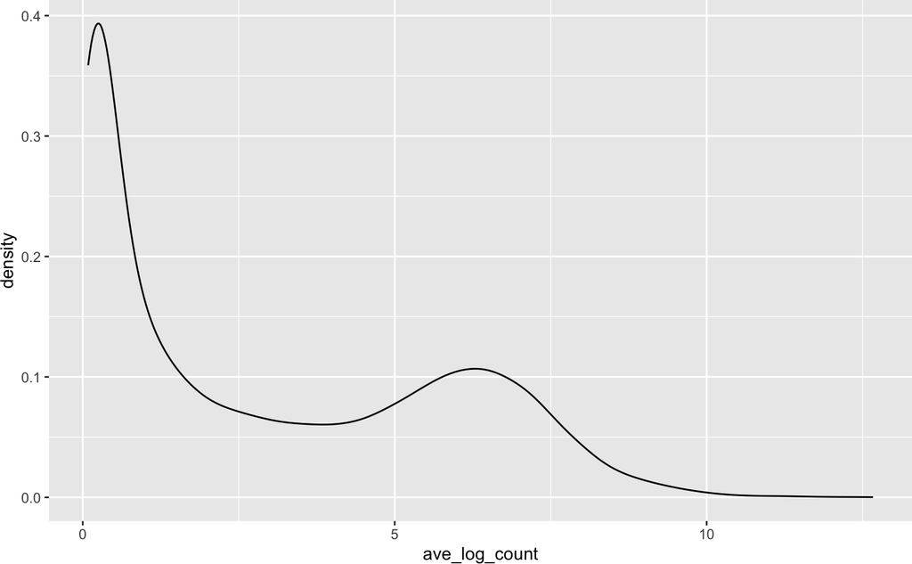

```r
ggplot(gene_summaries, aes(ave_log_count)) +
    geom_density()
```

# 3 End matter

## 3.2 Acknowledgements

Research reported in this tutorial was supported by the National Human Genome Research Institute and the National Cancer Institute of the National Institutes of Health under award numbers U24HG004059 (Bioconductor), U24HG010263 (AnVIL) and U24CA180996 (ITCR).